# Plotting DP values

Fco José Gómez

2024-04-25

# 1 Libraries

```r
library(ggplot2)
library(dplyr)
```

# 2 Analysis of the DP values

For obtaining the DP values from the variants that have been filtered by the chromosome and DP greather than 1 (DP>1) the command bcftools query is used. This file contains other information from each variant, such as the chromosome, the position and the type of variant, as well as the DP values.

The following command generates the file with these information:

```bash
bcftools query -f "%CHROM\t%POS\t%DP\t%TYPE\n" BCF_file_Davis_Cebas_Inrae_filtered_by_chr_dp1.bcf > Information_DP_BCF_file_merge_Davis_Cebas_Inrae_filtered_by_chr_dp1.txt
```

This information file contains 4 columns (Chromosome, Position, DP and Type), and it is loaded to a variable in order to calculate several statistics, such as the mean, standard deviation, first and third quartiles, the minimun and maximun values and the median.

After that, the minimun and maximun values of DP for filtering were established as the mean plus/minus the standard deviation.

```r
# Load the file
Davis_info <- read.delim2("Information_DP_BCF_file_merge_Davis_Cebas_Inrae_filtered_by_chr_dp1.txt", header=FALSE, sep="\t")

# Name the columns of the file
colnames(Davis_info) <- c("Chromosome", "Position", "DP", "Type")

## Calculate the statistics

# Mean
mean_dp <-  round(mean(Davis_info$DP),2)

# Median
median_dp <- median(Davis_info$DP)

# First quartile
first_q_dp <- quantile(Davis_info$DP,probs = 0.25)

# Third quartile
third_q_dp <- quantile(Davis_info$DP,probs = 0.75)

# Min DP value
min_dp_val <- min(Davis_info$DP)

# Max DP value
max_dp_val <- max(Davis_info$DP)

# Standard deviation
sd_DP <- round(sd(Davis_info$DP),2)

# Min DP value filtering
min_DP_filt <- mean_dp - sd_DP

# Max DP value filtering
max_DP_filt <- mean_dp + sd_DP

#Create a table for showing the statistics
table <- data.frame(min_dp_val,first_q_dp,median_dp,mean_dp,sd_DP,third_q_dp,max_dp_val,min_DP_filt,max_DP_filt)
colnames(table) <- c("Min", "1st Quantile", "Median", "Mean", "Standard deviation", "3rd Quantile", "Max", "Min DP threshold", "Max DP threshold")

# Show the table
table
```

|  | Min | 1st Quantile | Median | Mean | Standard deviation | 3rd Quantile | Max | Min DP threshold | Max DP threshold |
| --- | --- | --- | --- | --- | --- | --- | --- | --- | --- |
| 25% | 2 | 698 | 955 | 903.21 | 407.37 | 1088 | 13694 | 495.84 | 1310.58 |

As it can be observed, the minimun and maximum values for filtering by DP will be 496 and 1311 respectively, such as the DP are whole numbers

# 3 Ploting the DP values

A graphical representation of the distribution of DP values is made

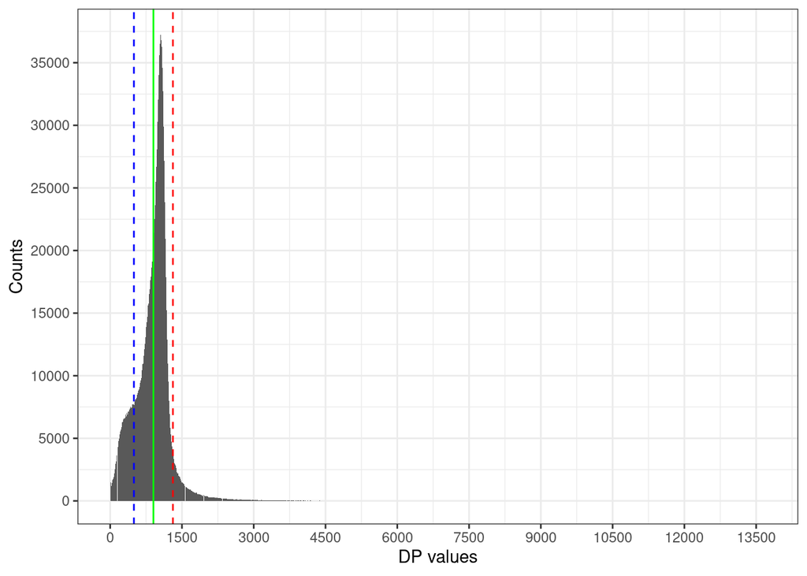

```r
# Plot for counting the values of DP
plot <- lot <- ggplot(Davis_info, aes(x=DP)) + geom_bar(stat = "count", width = 1)

# Establish the limit of the y-axis
max_counts <- max(ggplot_build(plot)$data[[1]]$count)

plot_def <- ggplot(Davis_info, aes(x=DP)) + geom_bar(stat = "count", width = 1) + theme_bw() + geom_vline(xintercept = 903.21, color = "green", linewidth = 0.5) +
  geom_vline(xintercept = 496, color = "blue", linetype = "dashed") + geom_vline(xintercept = 1311, color = "red", linetype = "dashed") +
  labs(x = "DP values", y="Counts") + scale_y_continuous(breaks = seq(0,max_counts, by=5000)) + scale_x_continuous(breaks = seq(0,max_dp_val,1500))

# Show the plot
plot_def
```

```r
write.csv2(table, "Analysis_DP_values_BCF_file_merge_Davis_Cebas_Inrae.csv", row.names = FALSE, col.names = TRUE, sep = ",", dec = ".")
```